# Functional tables analysis

Sergio Gozalo

20 de enero de 2021

## Loading necessary libraries

```r
library("vegan")
```

# EBI tables

## Table reading EBI

```r
ebi_go_abundances <- read.table("functional.tables/ERP112966_GO_abundances_v4.1.tsv", header = TRUE, row.names = 1, sep ="\t")
ebi_go_abundances$description <- NULL #Need to remove this column to work
ebi_go_abundances$category <- NULL #Need to remove this column to work
ebi_go_abundances <- t(ebi_go_abundances)

ebi_go.slim_abundances <- read.table("functional.tables/ERP112966_GO-slim_abundances_v4.1.tsv", header = TRUE, row.names = 1, sep ="\t")
ebi_go.slim_abundances$description <- NULL
ebi_go.slim_abundances$category <- NULL
ebi_go.slim_abundances <- t(ebi_go.slim_abundances)

ebi_ipr_abundances <- read.table("functional.tables/ERP112966_IPR_abundances_v4.1.tsv", header = TRUE, row.names = 1, sep ="\t")
ebi_ipr_abundances$description <- NULL
ebi_ipr_abundances$category <- NULL
ebi_ipr_abundances <- t(ebi_ipr_abundances)
```

## Richness

```r
# Subsampling
n1 <- min(rowSums(ebi_go_abundances))
ebi_go_abundances_ss <- rrarefy(ebi_go_abundances, n1)

n2 <- min(rowSums(ebi_go.slim_abundances))
ebi_go.slim_abundances_ss <- rrarefy(ebi_go.slim_abundances, n2)

n3 <- min(rowSums(ebi_ipr_abundances))
ebi_ipr_abundances_ss <- rrarefy(ebi_ipr_abundances, n3)

# Richness

ebi_go_abundances_richness <- estimateR(ebi_go_abundances_ss)
ebi_go.slim_abundances_richness <- estimateR(ebi_go.slim_abundances_ss)
ebi_ipr_abundances_richness <- estimateR(ebi_ipr_abundances_ss)
```

## NMDS

### GO

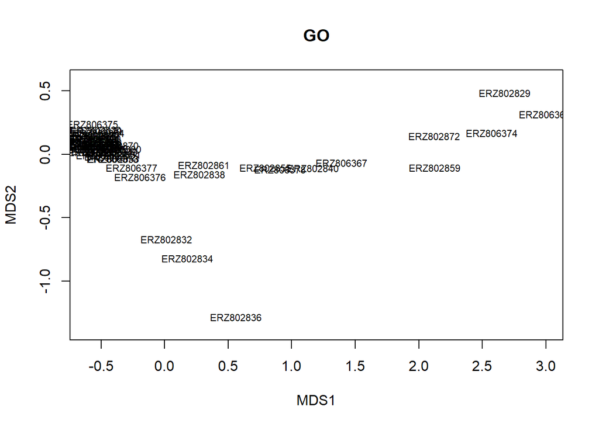

```r
ebi_go_abundances_ss_bray <- vegdist(ebi_go_abundances_ss, method="bray")
ebi_go_abundances_ss_bray.nmds <- monoMDS(ebi_go_abundances_ss_bray)

plot(ebi_go_abundances_ss_bray.nmds, main = "GO")
```

Se observa un cluster, el resto son independientes.

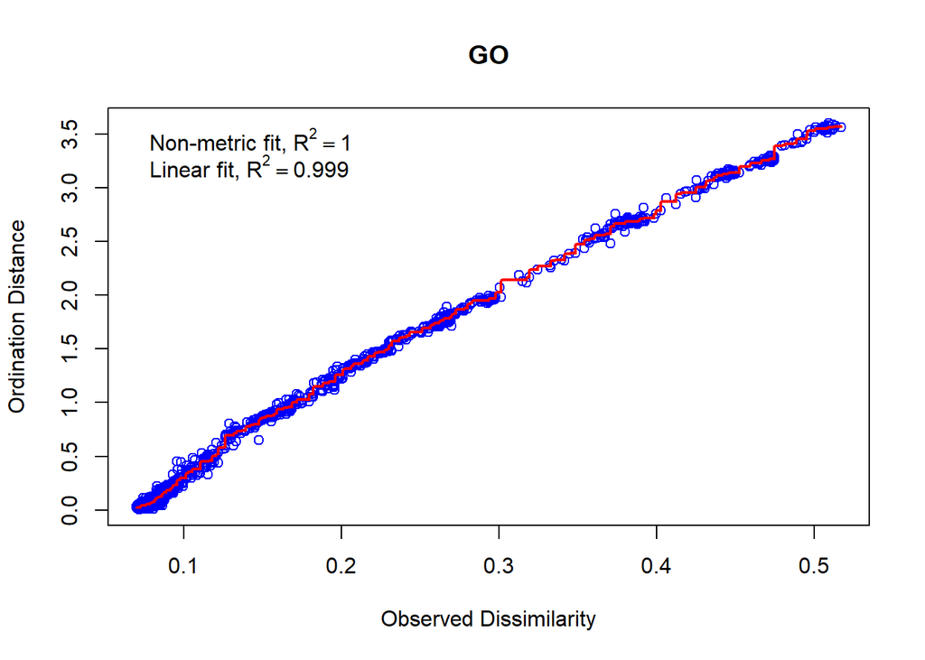

```r
stressplot(ebi_go_abundances_ss_bray.nmds, main = "GO")
```

### GO-SLIM

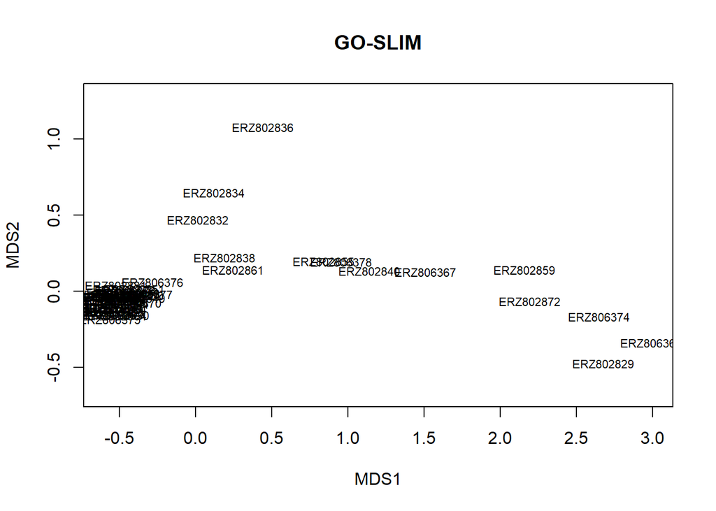

```r
ebi_go.slim_abundances_ss_bray <- vegdist(ebi_go.slim_abundances_ss, method="bray")
ebi_go.slim_abundances_ss_bray.nmds <- monoMDS(ebi_go.slim_abundances_ss_bray)

plot(ebi_go.slim_abundances_ss_bray.nmds, main = "GO-SLIM")
```

Se observa un cluster, el resto son independientes.

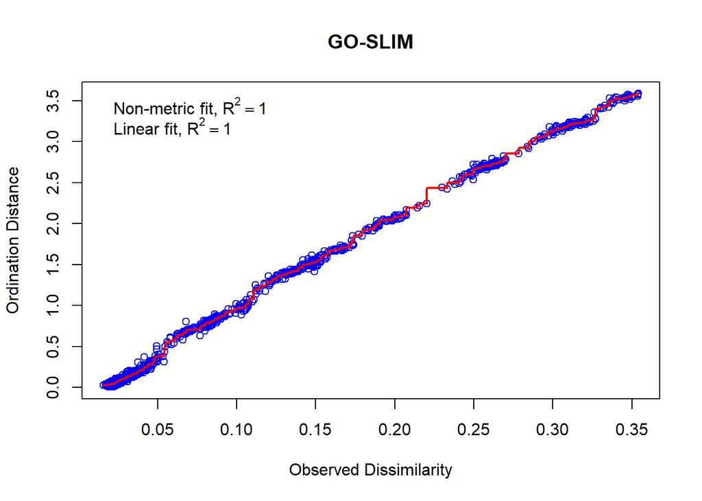

```r
stressplot(ebi_go.slim_abundances_ss_bray.nmds, main = "GO-SLIM")
```

### IPR

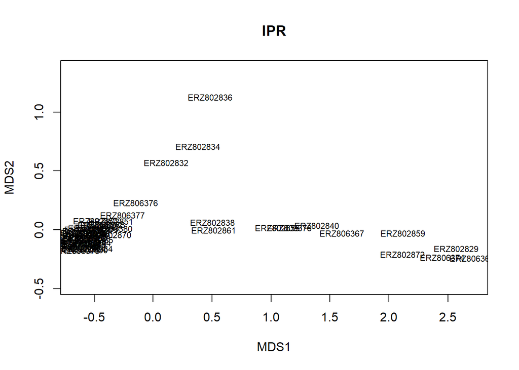

```r
ebi_ipr_abundances_ss_bray <- vegdist(ebi_ipr_abundances_ss, method="bray")
ebi_ipr_abundances_ss_bray.nmds <- monoMDS(ebi_ipr_abundances_ss_bray)

plot(ebi_ipr_abundances_ss_bray.nmds, main = "IPR")
```

Se ve un cluster.

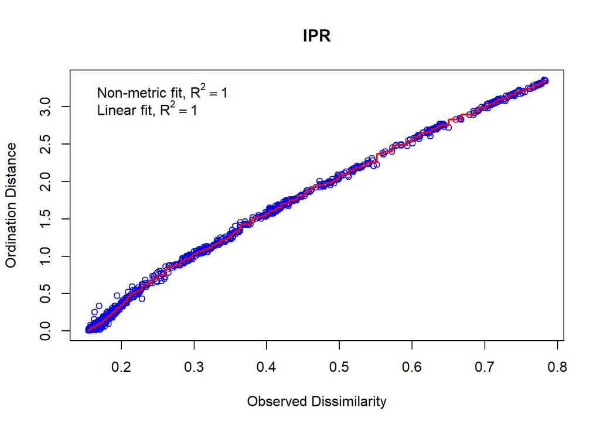

```r
stressplot(ebi_ipr_abundances_ss_bray.nmds, main = "IPR")
```

## Dendograms

### GO

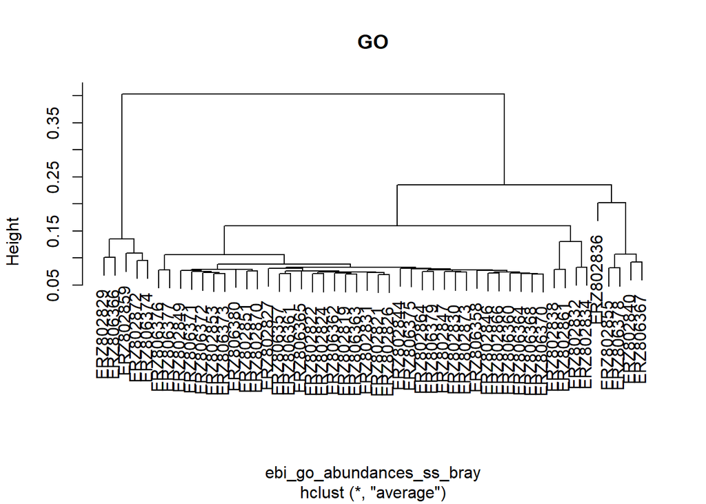

```r
ebi_go_abundances_ss_bray_hclust <- hclust(ebi_go_abundances_ss_bray, method="average")
plot(ebi_go_abundances_ss_bray_hclust, main = "GO")
```

Se observan dos grupos principales, uno de ellos es mucho mas grande y tiene bastantes subdivisiones, siendo las dos primeras.

### GO-SLIM

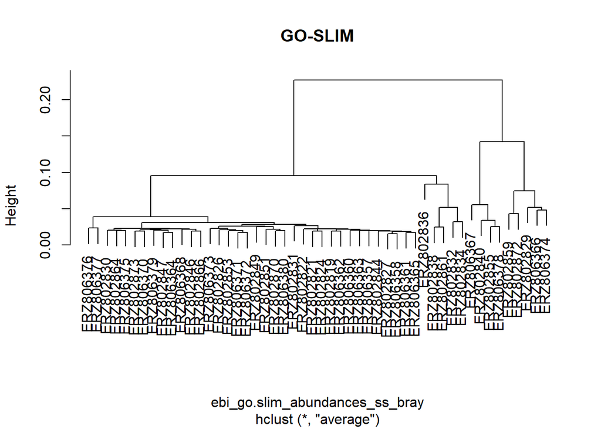

```r
ebi_go.slim_abundances_ss_bray_hclust <- hclust(ebi_go.slim_abundances_ss_bray, method="average")
plot(ebi_go.slim_abundances_ss_bray_hclust, main = "GO-SLIM")
```

Muy parecido al GO, pero con distinta longitud de ramas.

### IPR

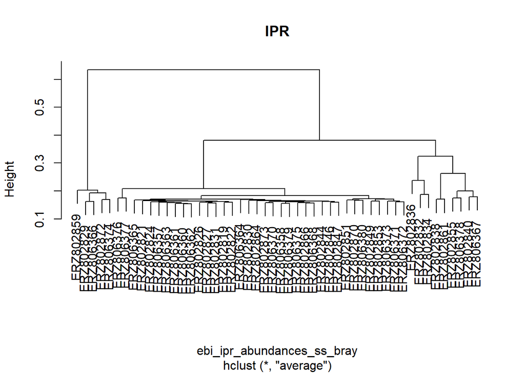

```r
ebi_ipr_abundances_ss_bray_hclust <- hclust(ebi_ipr_abundances_ss_bray, method="average")
plot(ebi_ipr_abundances_ss_bray_hclust, main = "IPR")
```

Se observan dos grupos principales, uno de ellos es mucho mas grande y tiene bastantes subdivisiones, distribuidas de distinta forma que en GO.

# ICM tables

## Table reading ICM

```r
icm_cog_meta <- t(read.table("functional.tables/EMOSE-GC_ICM_250bp_COG.lengthNorm.metaGsizeNorm.counts.tbl", header = TRUE, sep = "\t", row.names = 1))
icm_cog_scg <- t(read.table("functional.tables/EMOSE-GC_ICM_250bp_COG.lengthNorm.SCGnorm.counts.tbl", header = TRUE, sep = "\t", row.names = 1))

icm_kegg_meta <- t(read.table("functional.tables/EMOSE-GC_ICM_250bp_KEGG.ko.lengthNorm.metaGsizeNorm.counts.tbl", header = TRUE, sep = "\t", row.names = 1))
icm_kegg_scg <- t(read.table("functional.tables/EMOSE-GC_ICM_250bp_KEGG.ko.lengthNorm.SCGnorm.counts.tbl", header = TRUE, sep = "\t", row.names = 1))

icm_pfam_meta <- t(read.table("functional.tables/EMOSE-GC_ICM_250bp_pfam.lengthNorm.metaGsizeNorm.counts.tbl", header = TRUE, sep = "\t", row.names = 1))
icm_pfam_scg <- t(read.table("functional.tables/EMOSE-GC_ICM_250bp_pfam.lengthNorm.SCGnorm.counts.tbl", header = TRUE, sep = "\t", row.names = 1))
```

## NMDs

### COG

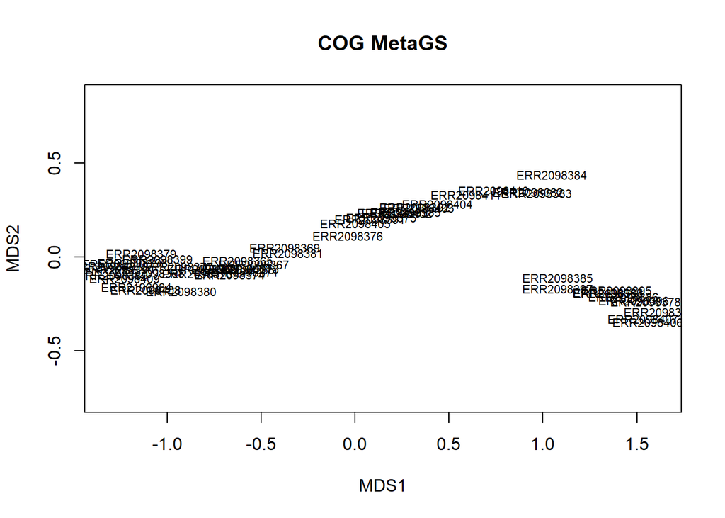

```r
icm_cog_meta_bray <- vegdist(icm_cog_meta, method="bray")
icm_cog_scg_bray <- vegdist(icm_cog_scg, method="bray")

icm_cog_meta_bray.nmds <- monoMDS(icm_cog_meta_bray)
icm_cog_scg_bray.nmds <- monoMDS(icm_cog_scg_bray)

# MetaGS
plot(icm_cog_meta_bray.nmds, main = "COG MetaGS")
```

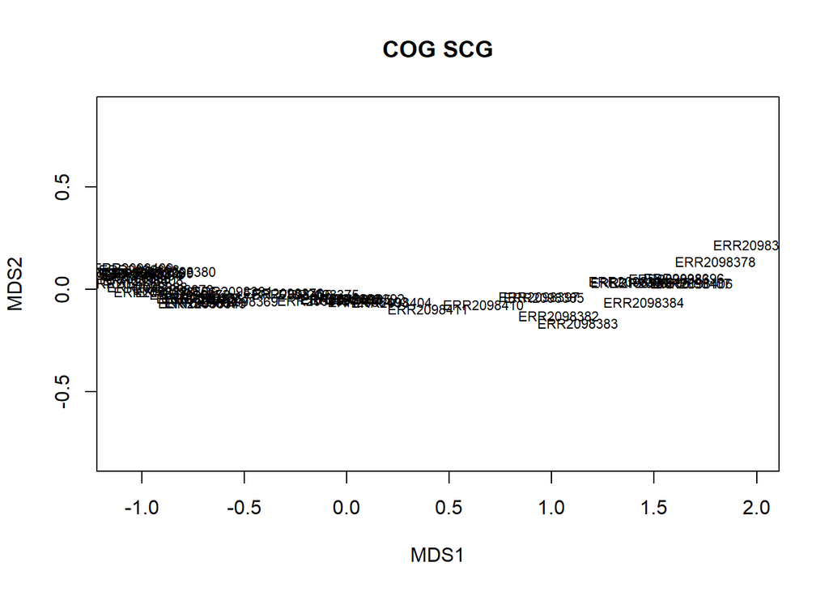

```r
# SC
plot(icm_cog_scg_bray.nmds, main = "COG SCG")
```

COG MetaGS: Se pueden observar 4 clusters distintos, tres de ellos cercanos y uno mas distante y sin relación.

COG SCG: Se peuden observar 3 clusters, dos de ellos proximos y uno mas separado pero que aun parece mantener una relación.

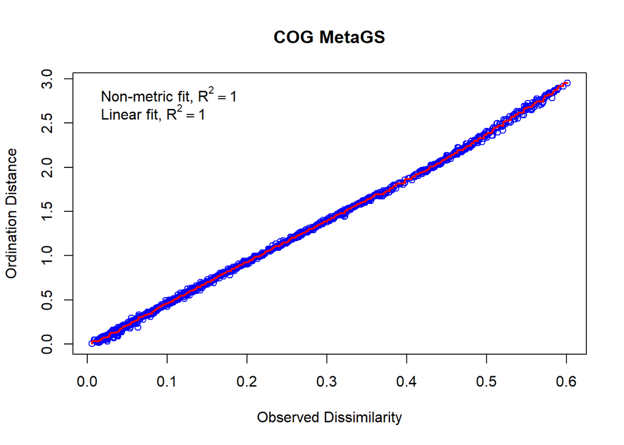

```r
stressplot(icm_cog_meta_bray.nmds, main = "COG MetaGS")
```

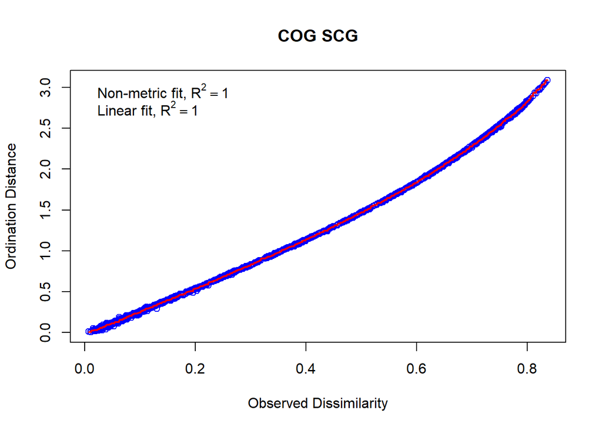

```r
stressplot(icm_cog_scg_bray.nmds, main = "COG SCG")
```

### KEGG

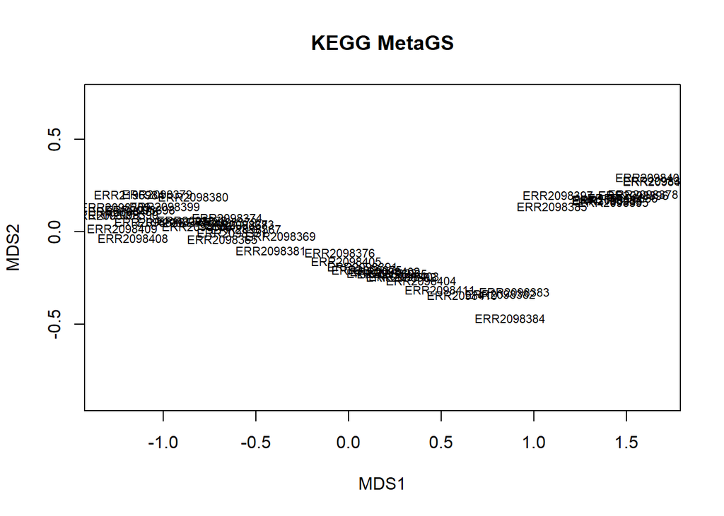

```r
icm_kegg_meta_bray <-vegdist(icm_kegg_meta, method="bray")
icm_kegg_scg_bray <-vegdist(icm_kegg_scg, method="bray")

icm_kegg_meta_bray.nmds <- monoMDS(icm_kegg_meta_bray)
icm_kegg_scg_bray.nmds <- monoMDS(icm_kegg_scg_bray)

# MetaGS
plot(icm_kegg_meta_bray.nmds, main = "KEGG MetaGS")
```

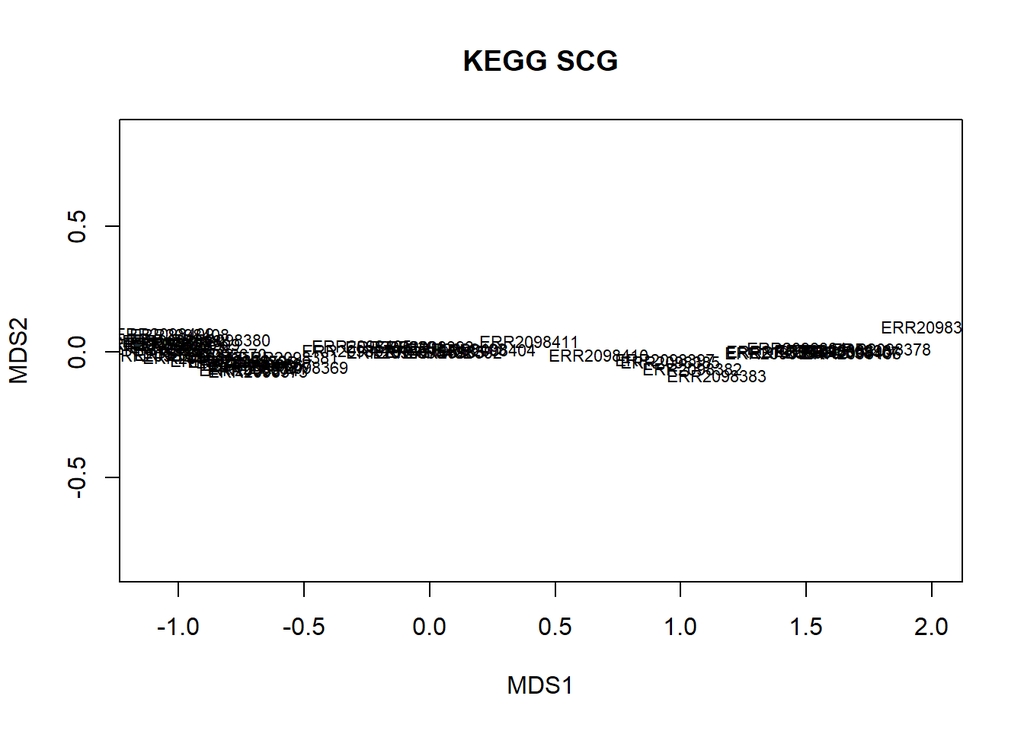

```r
# SC
plot(icm_kegg_scg_bray.nmds, main = "KEGG SCG")
```

KEGG MetaGS: Se observan 4 clusters, en este caso parecen mejor separados, aunque dos de ellos son bastante proximos.

KEGG SCG: Se observan 4 clusters, dos de ellos muy proximos, cerca otro y el cuarto parece bastante alejado.

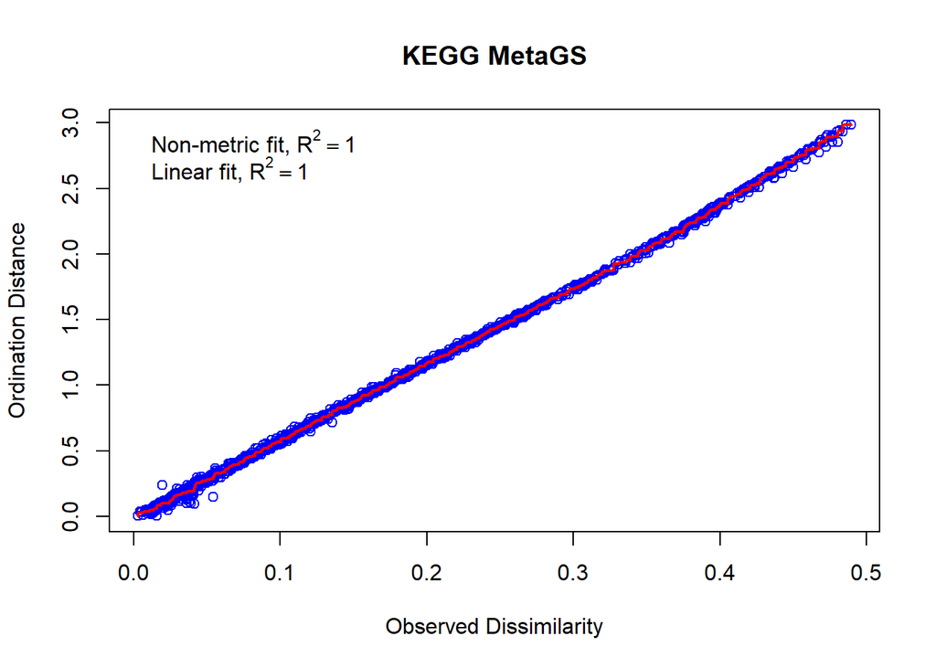

```r
stressplot(icm_kegg_meta_bray.nmds, main = "KEGG MetaGS")
```

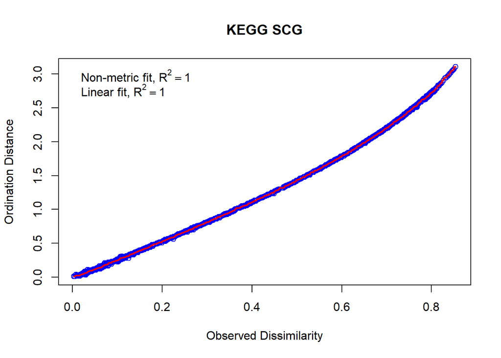

```r
stressplot(icm_kegg_scg_bray.nmds, main = "KEGG SCG")
```

### PFAM

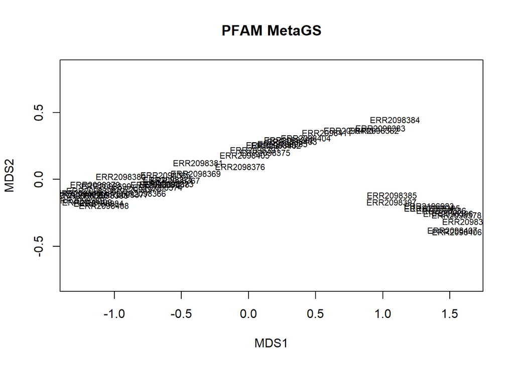

```r
icm_pfam_meta_bray <-vegdist(icm_pfam_meta, method="bray")
icm_pfam_scg_bray <-vegdist(icm_pfam_scg, method="bray")

icm_pfam_meta_bray.nmds <- monoMDS(icm_pfam_meta_bray)
icm_pfam_scg_bray.nmds <- monoMDS(icm_pfam_scg_bray)

# MetaGS
plot(icm_pfam_meta_bray.nmds, main = "PFAM MetaGS")
```

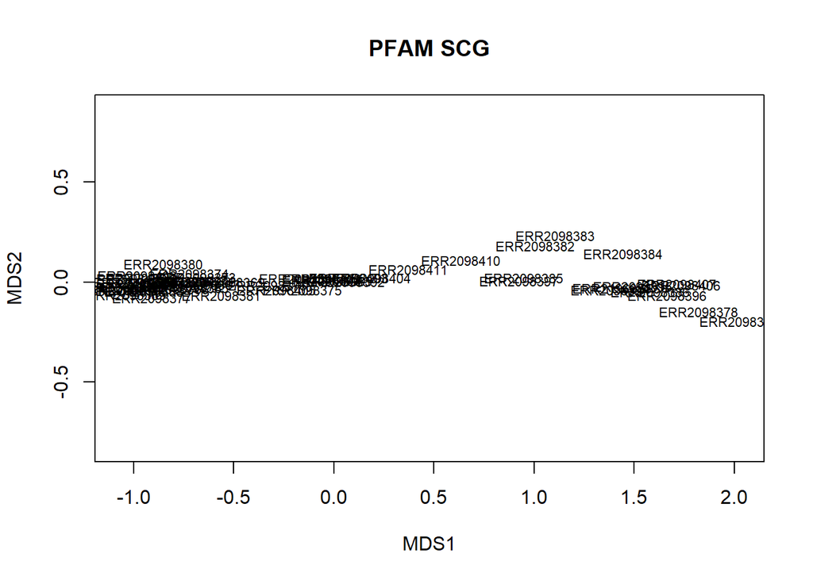

```r
# SC
plot(icm_pfam_scg_bray.nmds, main = "PFAM SCG")
```

PFAM MetaGS: En este caso los clusters no estan tan bien definidos, pero se pueden llegar a distinguir 4, dos muy cercanos, un tercero que mantiene relacion y el cuarto totalmente aislado.

PFAM SCG: Se observan 4 clusters, dos de ellos casi solapados, el tercero bastante cerca (mas que en los casos anteriores) y el cuarto aislado.

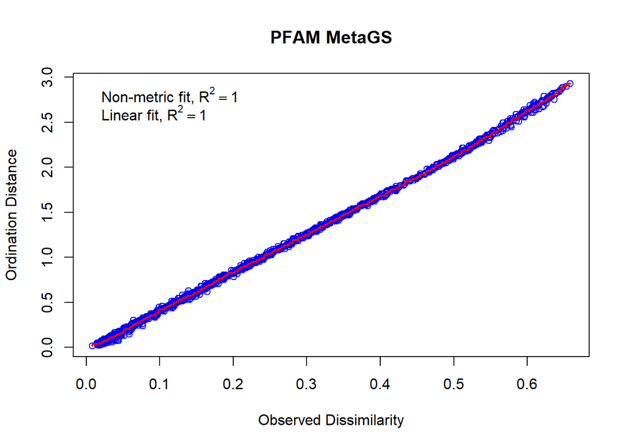

```r
stressplot(icm_pfam_meta_bray.nmds, main = "PFAM MetaGS")
```

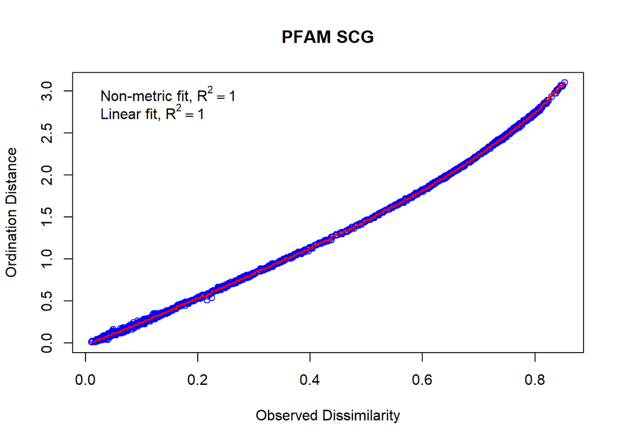

```r
stressplot(icm_pfam_scg_bray.nmds, main = "PFAM SCG")
```

## Dendograms

### COG

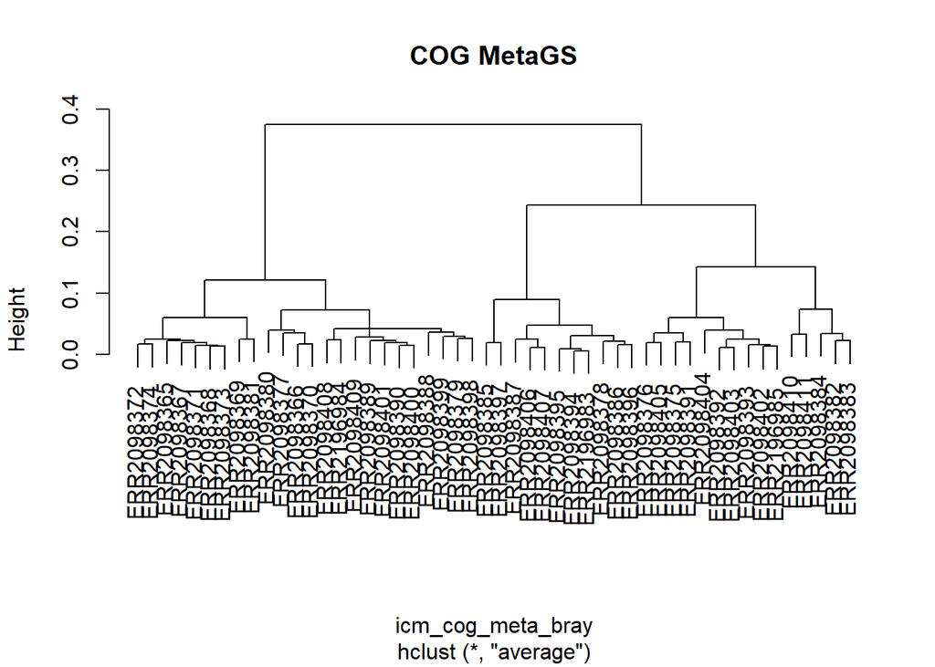

```r
icm_cog_meta_bray_hclust <- hclust(icm_cog_meta_bray, method="average")
plot(icm_cog_meta_bray_hclust, main = "COG MetaGS")
```

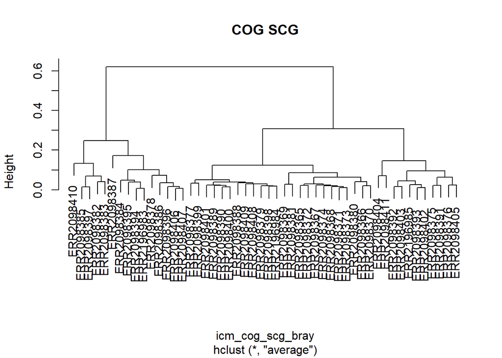

```r
icm_cog_scg_bray_hclust <- hclust(icm_cog_scg_bray, method="average")
plot(icm_cog_scg_bray_hclust, main = "COG SCG")
```

COG MetaGS: Se observan dos grupos principales que, a su vez, tienen dos subgrupos. Concuerda con los 4 clusters.

COG SCG: Se observan dos grupos principales, uno de ellos parece tener una subdivision importante, en el otro parece no ser tan importante. Concuerda con los clusters.

### KEGG

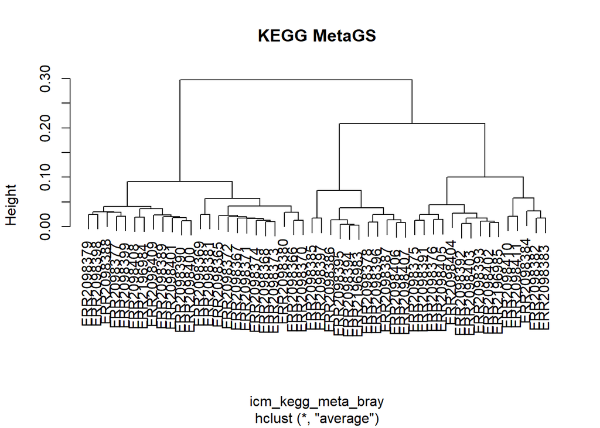

```r
icm_kegg_meta_bray_hclust <-hclust(icm_kegg_meta_bray, method="average")
plot(icm_kegg_meta_bray_hclust, main = "KEGG MetaGS")
```

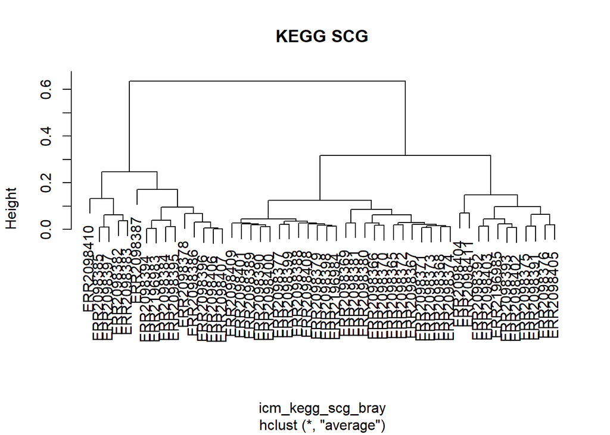

```r
icm_kegg_scg_bray_hclust <-hclust(icm_kegg_scg_bray, method="average")
plot(icm_kegg_scg_bray_hclust, main = "KEGG SCG")
```

KEGG MetaGS: Se pueden observar dos grupos principales y cada uno de ellos dividido en otros dos grupos principales. Concuerda con los clusters.

KEGG SCG: Se pueden observar 2 grupos principales, divididos en otros dos grupos principales cada uno. Concuerda con los clusters.

Muy parecidos a los obtenidos usando COG.

### PFAM

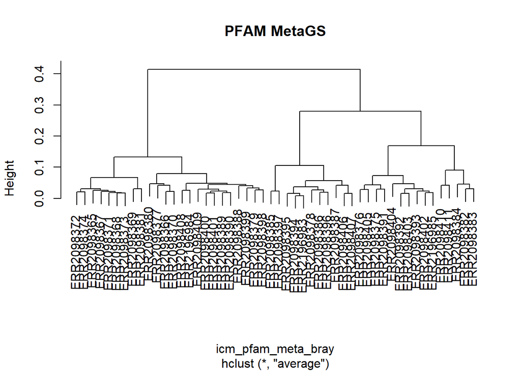

```r
icm_pfam_meta_bray_hclust <-hclust(icm_pfam_meta_bray, method="average")
plot(icm_pfam_meta_bray_hclust, main = "PFAM MetaGS")
```

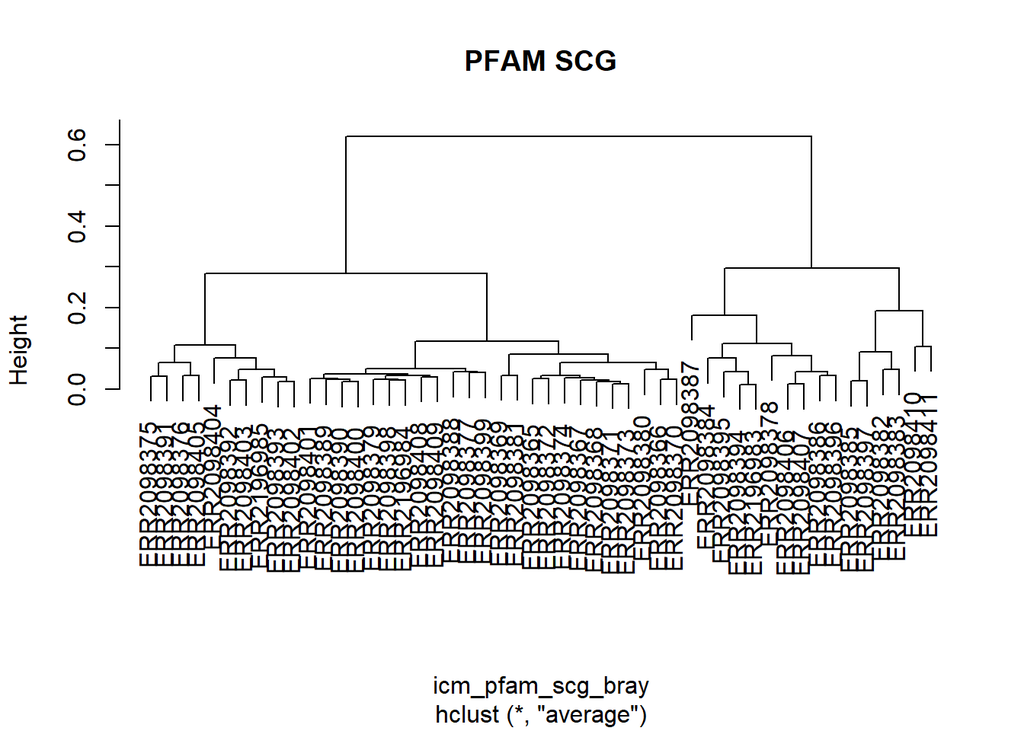

```r
icm_pfam_scg_bray_hclust <-hclust(icm_pfam_scg_bray, method="average")
plot(icm_pfam_scg_bray_hclust, main = "PFAM SCG")
```

PFAM MetaGS: Se pueden observar 2 grupos principales, divididos en otros dos grupos principales cada uno, pero a partir de ahi las divisiones son muy cortas, familias proximas.

PFAM SCG: En este caso, despues de la division principal, en uno de los grupos se puede observar que las relaciones son muy cercanas.

En ambos casos concuerda con los clusters poco definidos, que implican familias próximas.

## Conclusion EBI vs ICM

En ambos casos los NMDs coinciden con los dendogramas, son coherentes. Por otra parte, los datos obtenidos por el ICM tienen mucha mas capacidad para clasificar en diferentes familias o genes y manteniendo la coherencia entre NMDS y dendogramas.

Por tanto, considero que el tratamiento/pipeline utilizada en el ICM, con la finalidad de clasificación, es bastante más útil que la usada en el IBM, Mgnify.

# OTU tables MiTags

```r
otu_mitags <- (read.delim("functional.tables/otu_table97.txt", header = TRUE, sep = "\t"))
otu_mitags$OTUId <- NULL
otu_mitags <- t(otu_mitags)
```

## Richness

```r
otu_mitags_ss <- rrarefy(otu_mitags, min(rowSums(otu_mitags)))
richness <- estimateR(otu_mitags_ss)
richness
```

```
##          ERR2098365 ERR2098366 ERR2098367 ERR2098368 ERR2098369 ERR2098370
## S.obs    3363.00000 3374.00000 3333.00000 3165.00000 3230.00000  2976.0000
## S.chao1  5469.32275 5280.50671 5173.11037 5064.61509 4991.76482  4525.3908
## se.chao1  146.29947  132.82532  128.94073  138.45079  129.74630   118.6415
## S.ACE    5599.49572 5426.78056 5397.62244 5059.81365 4914.96325  4537.7900
## se.ACE     43.63723   42.53637   41.94795   39.92445   38.64692    37.0613
##          ERR2098371 ERR2098372 ERR2098373 ERR2098374 ERR2098375 ERR2098376
## S.obs    3030.00000 3063.00000  3031.0000 3055.00000 3195.00000 2962.00000
## S.chao1  4469.29135 4665.62644  4544.2404 4638.86578 4630.41667 4683.07880
## se.chao1  109.65644  120.24606   114.9466  118.62448  104.96072  126.56533
## S.ACE    4536.87707 4759.11747  4562.9983 4723.25383 4808.91664 4804.85855
## se.ACE     36.67856   38.57236    36.6697   38.06524   38.03016   39.70863
##          ERR2098377 ERR2098378 ERR2098379 ERR2098380 ERR2098381 ERR2098382
## S.obs    3147.00000  814.00000 2889.00000 2743.00000 3317.00000 3102.00000
## S.chao1  5176.77049 1977.29592 4746.54098 4111.75688 5046.45486 4426.87342
## se.chao1  148.88854  161.79962  144.50553  111.88622  124.06572  101.46854
## S.ACE    5116.56968 2104.16728 4592.67382 4034.78175 5133.79031 4442.62753
## se.ACE     40.58409   31.25647   37.77476   33.82777   39.94368   35.52303
##          ERR2098383 ERR2098384 ERR2098385 ERR2098386 ERR2098387 ERR2098388
## S.obs    3082.00000 2705.00000 1910.00000 1199.00000  582.00000 2952.00000
## S.chao1  4839.57143 3696.08911 4072.38033 2749.25862 1168.57692 4729.55032
## se.chao1  128.81029   82.83315  183.67138  168.46345   97.45972  135.43141
## S.ACE    4880.66091 3784.97501 4306.21006 3010.55170 1199.26033 4713.02496
## se.ACE     40.22799   32.55506   42.12434   36.71616   22.06295   38.07183
##          ERR2098389 ERR2098390 ERR2098391 ERR2098392 ERR2098393 ERR2098394
## S.obs    2843.00000 2840.00000 3609.00000 3291.00000 3614.00000 1258.00000
## S.chao1  4395.72451 4273.72428 5406.11826 4516.00985 5325.26205 2793.24631
## se.chao1  121.79737  112.35032  122.32980   92.74273  117.84620  158.23393
## S.ACE    4442.64669 4382.22100 5577.47170 4585.10912 5454.03599 3381.04808
## se.ACE     37.52637   36.95821   41.85992   35.20883   40.66965   39.81074
##          ERR2098395 ERR2098396 ERR2098397 ERR2098398 ERR2098399 ERR2098400
## S.obs    1220.00000 1081.00000 1869.00000 2676.00000 2761.00000  2853.0000
## S.chao1  2857.35465 2391.57962 3503.57015 4231.42500 4396.57178  4329.3438
## se.chao1  177.29013  151.32573  140.72532  127.54583  131.76078   115.4732
## S.ACE    3092.50941 2599.43738 3812.14828 4119.92378 4258.43487  4398.1012
## se.ACE     36.70427   32.43883   40.92222   35.19017   35.78393    36.5688
##          ERR2098401 ERR2098402 ERR2098403 ERR2098404 ERR2098405 ERR2098406
## S.obs    2752.00000 3557.00000 3523.00000 3696.00000 3704.00000 1006.00000
## S.chao1  4250.92273 5437.02475 5235.67145 5498.63650 6008.43820 2362.82576
## se.chao1  120.09193  130.65984  119.96784  121.70953  152.82057  165.86778
## S.ACE    4253.20203 5405.97072 5275.51294 5597.24266 6051.38530 2485.56146
## se.ACE     36.20664   40.16997   39.58056   40.43757   44.14486   32.23858
##          ERR2098407 ERR2098408 ERR2098409 ERR2098410 ERR2098411 ERR2196983
## S.obs     967.00000 2490.00000 2475.00000  3538.0000 3554.00000 1391.00000
## S.chao1  2534.21429 3622.72953 3996.91549  5590.5879 5563.76804 3602.73797
## se.chao1  199.74233   98.40111  130.17393   140.9477  139.65963  223.06296
## S.ACE    2570.47155 3621.32081 3915.62656  5501.9519 5480.93121 4072.97089
## se.ACE     33.26482   32.00212   35.13967    40.8614   40.68882   43.99476
##          ERR2196984 ERR2196985
## S.obs    2847.00000 3775.00000
## S.chao1  4547.21525 6050.15931
## se.chao1  132.51512  150.40233
## S.ACE    4531.45671 6051.51826
## se.ACE     37.75106   43.61765
```

## Rarefaction

```r
#otu_rare <- rarefaction(otu_mitags_ss)
```

No he sido capaz de correr este plot.

## Rarecurve

```r
#otu_rcurve <- rarecurve(otu_mitags_ss)
```

## Acumulation curve

```r
#otu_acc <- specaccum(otu_mitags_ss, method = "exact", permutations = 1000)
#plot(otu_acc)
```

## Eveness

```
## Error in glm.fit(x = structure(c(1, 1, 1, 1, 1, 1, 1, 1, 1, 1, 1, 1, 1,  :
##   NA/NaN/Inf in 'x'
```

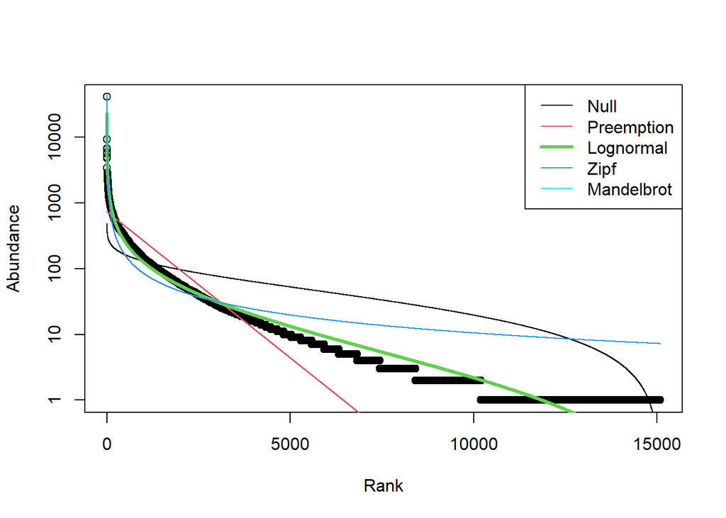

```r
plot(radfit(colSums(otu_mitags_ss)))
```

## Preston fit

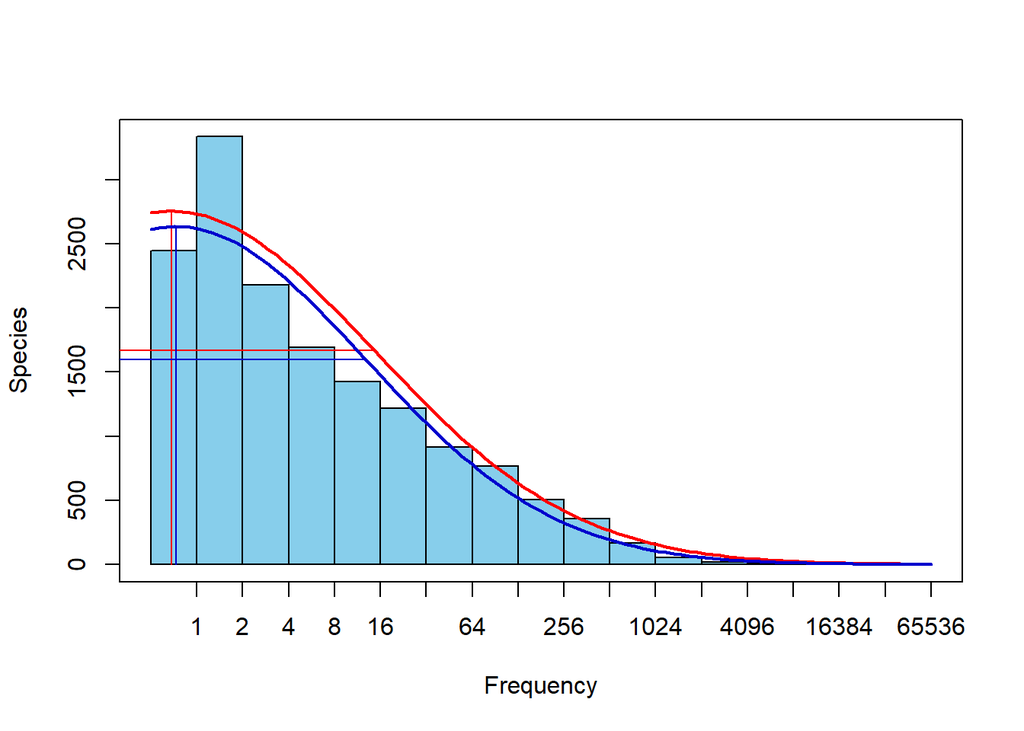

```r
otu_preston<-prestonfit(colSums(otu_mitags_ss))
otu_prestondistr<-prestondistr(colSums(otu_mitags_ss))
plot(otu_preston)
lines(otu_prestondistr, line.col="blue3")
```

## NMDS

```r
otu_mitags_ss_bray <- vegdist(otu_mitags_ss, method="bray")
otu_mitags_ss_bray.nmds <- monoMDS(otu_mitags_ss_bray)

otu_mitags_ss_bray.nmds
```

```
##
## Call:
## monoMDS(dist = otu_mitags_ss_bray)
##
## Non-metric Multidimensional Scaling
##
## 50 points, dissimilarity 'bray', call 'vegdist(x = otu_mitags_ss, method = "bray")'
##
## Dimensions: 2
## Stress:     0.03149035
## Stress type 1, weak ties
## Scores scaled to unit root mean square, rotated to principal components
## Stopped after 115 iterations: Scale factor of gradient nearly zero (< sfgrmin)
```

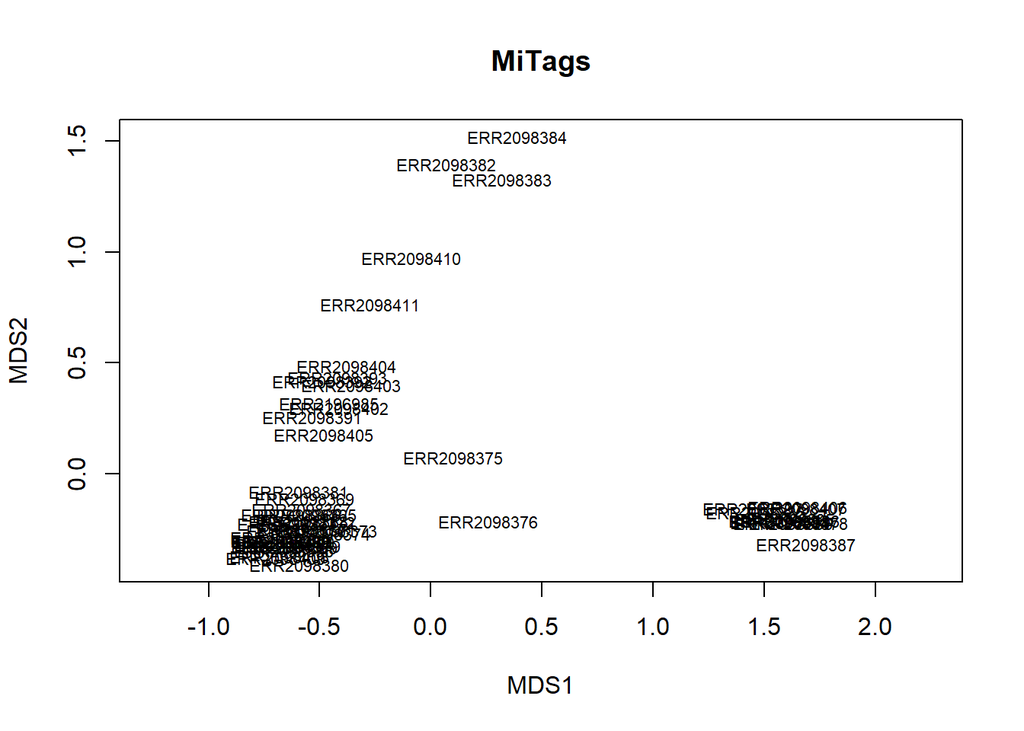

```r
plot(otu_mitags_ss_bray.nmds, main = "MiTags")
```

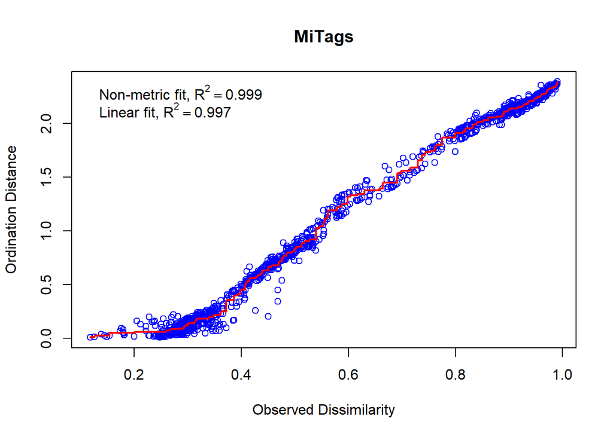

```r
stressplot(otu_mitags_ss_bray.nmds, main = "MiTags")
```

## UPGMA

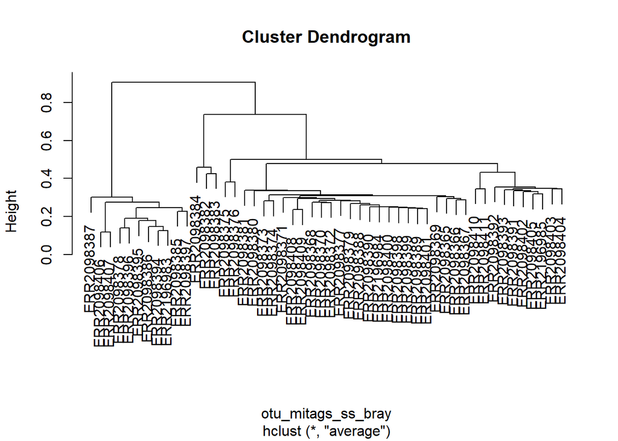

```r
otu_mitags_ss_hclust <- hclust(otu_mitags_ss_bray, "average")
plot(otu_mitags_ss_hclust)
```

```r
otu_mitags_ss_hclust
```

```
##
## Call:
## hclust(d = otu_mitags_ss_bray, method = "average")
##
## Cluster method   : average
## Distance         : bray
## Number of objects: 50
```

## DCA

```r
otu_dca <- decorana(otu_mitags_ss)
```

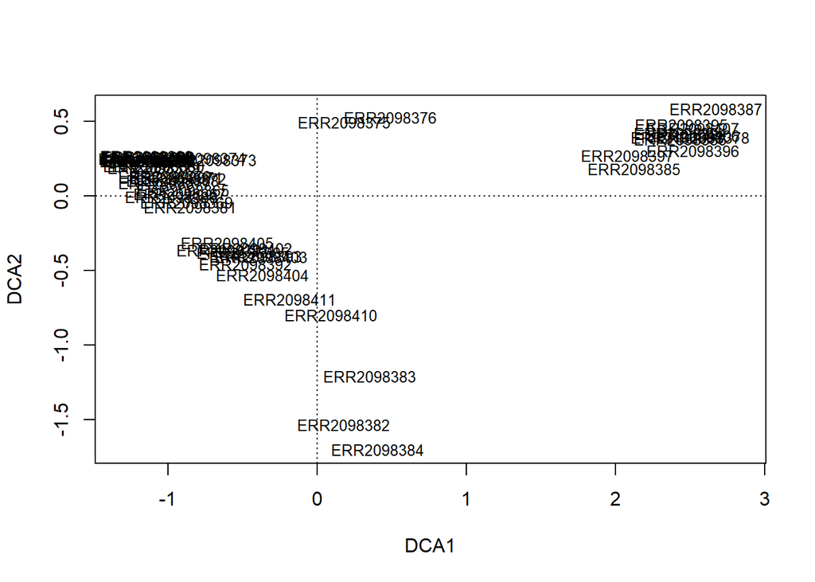

```r
plot(otu_dca, display = "sites")
```

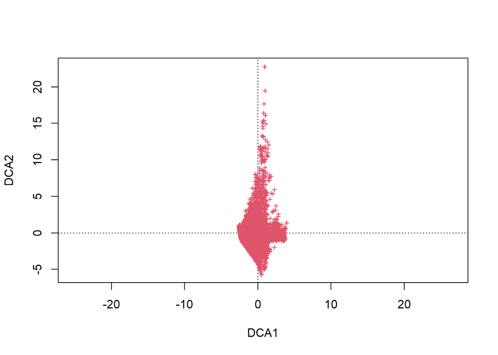

```r
plot(otu_dca, display = "species")
```

## Mantel test

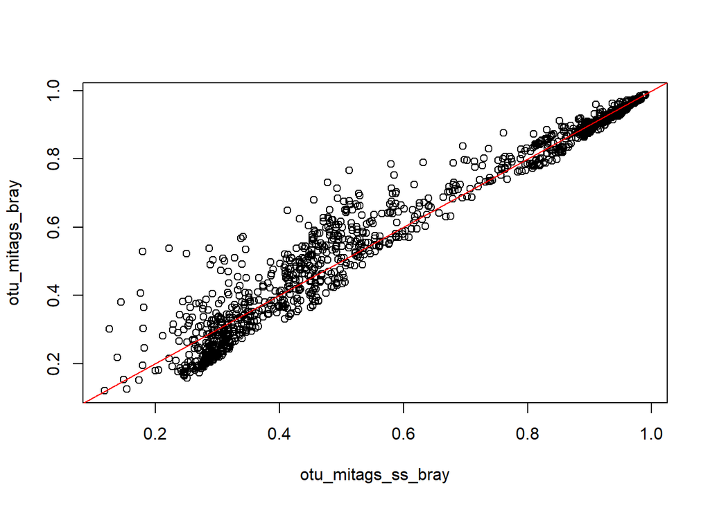

```r
otu_mitags_bray <- vegdist(otu_mitags, method="bray")
plot(otu_mitags_ss_bray,otu_mitags_bray)
abline(0,1, col = "red")
```

```r
mantel(otu_mitags_ss_bray,otu_mitags_bray)
```

```
##
## Mantel statistic based on Pearson's product-moment correlation
##
## Call:
## mantel(xdis = otu_mitags_ss_bray, ydis = otu_mitags_bray)
##
## Mantel statistic r: 0.9756
##       Significance: 0.001
##
## Upper quantiles of permutations (null model):
##   90%   95% 97.5%   99%
## 0.075 0.109 0.156 0.189
## Permutation: free
## Number of permutations: 999
```

Una buena correlación implica que el subsampling es correcto y que no afecta negativamente al analysis.

## Conclusión ITags vs MiTags

Comparando los plots obtenidos por MiTags e ITags (16S), puedo ver diferencias, pero no sabria interpretarlas.

Ahora bien, leyendo y utilizando el paper "Metagenomic 16S rDNA Illumina tags are a powerfulalternative to amplicon sequencing to explore diversityand structure of microbial communities", se puede deducir que usando MiTags la detección de OTUs es mas óptima.